# Map Algebra for Site Selection in R

## **Condition 4**

The distance from an existing road should be less than 500 metres. The road raster layer is discrete and has 3 classes with values;

- 0 - No road
- 1 - Dirt road
- 2 - Tarmac road

The `reclassify()` function would be use to reclassify values into **0(No roads)** and **1(Dirt and Tarmac roads)**.

```r
RclRoads <- reclassify(roads,
                       rcl = matrix(c(0,0,0, # from 0 to 0 ->0
                                      1,2,1),# from 1 to 2 ->1
                                    ncol = 3,byrow = TRUE))

# Lets now map the 0 values of rclRoads layer to NA to allow for distance computation.
RclRoads[RclRoads==0]<- NA #We could have equally set 0 values to NA within the reclassify matrix.

unique(values(RclRoads))
[1] NA  1
```

Lets now compute the distances for the reclassified road Map using the `distance()` function.

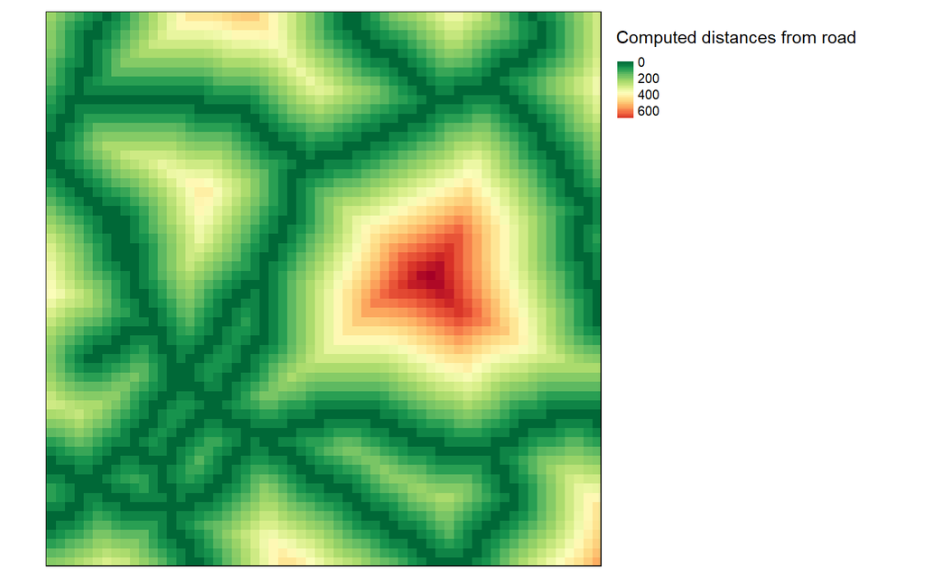

```r
RoadDist<- distance(RclRoads)

tm_shape(RoadDist)+
  tm_raster(style = 'cont',
            title ="Computed distances from road" ,
            palette = "-RdYlGn")+
  tm_layout(legend.outside= TRUE ,
            legend.outside.position = "right")
```

Lets enforce condition **4.The distance from an existing road should be less than 500 metres**

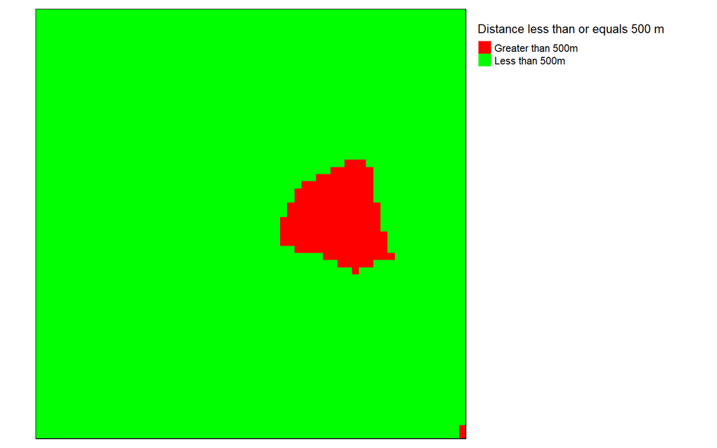

```r
LessThan500m <- RoadDist <= 500

#lets style the layer
tm_shape(LessThan500m)+
  tm_raster(style = "cat",
            title = "Distance less than or equals 500 m",
            labels = c("Greater than 500m","Less than 500m"),
            palette = c("red","green"))+
  tm_layout(legend.outside= TRUE ,
            legend.outside.position = "right")
```

Lets combine all the criteria. In R we would multiply all the boolean condition.

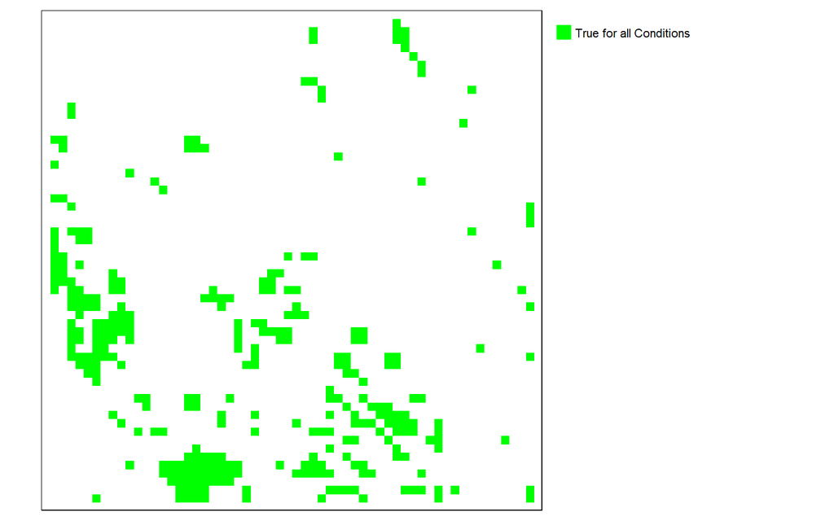

```r
Niomgo <- NoIndustry*NoBuilding*NoWater*NoRoad*SlopeNotSteep*LessThan500m

#Lets set all zero pxels to NA. Weare aonly interested in pixels with value =1(Boolen True).
Niomgo[Niomgo==0]<- NA

#Lets chechk to be sure all zero's are now NA leaving values of 1 only.
summary(Niomgo)
        layer
Min.        1
1st Qu.     1
Median      1
3rd Qu.     1
Max.        1
NA's     3292


tm_shape(Niomgo)+
  tm_raster(style = "cat",
            title = "",
            labels = "True for all Conditions",
            palette = "green")+
  tm_layout(legend.outside= TRUE ,legend.outside.position = "right")
```